# Tarea11

2025-06-16

## Contexto

Para este ejercicio usaremos los datos de medidas anatómicas recolectados por Heinz et al. (2003) que ya hemos utilizado en los ejercicios prácticos anteriores (disponibles en el archivo “EP09 Datos.csv”), con la adición de las variables IMC y EN consideradas en el ejercicio práctico anterior. Vamos a realizar lo siguiente:

1. Cargar los datos y crear las variables IMC y EN. Ademas de la semilla a utilizara que son los primeros 5 digitos del RUN del miembro con mayor edad del equipo, lo cual para este caso la semilla es 21003.
2. Seleccionar una muestra de 100 personass, asegurando que la mitad tenga estado nutricional de sobrepeso y la otra mitad no.
3. Para despues crear tres modelos:
- Regresión Lineal Multiple (RLM) con búsqueda exhaustiva.
- Regresión Lineal Multiple (RLM) con RFE.
- Regresión Logítica (RLOG) con RFE y con mejor curva ROC.

Primero se cargan lo datos del archivo “EP09 Datos.csv” y se crean las variables IMC y EN. Luego, se selecciona una muestra de 100 personas, asegurando que la mitad tenga estado nutricional de sobrepeso y la otra mitad no.

```r
library(dplyr)
library(leaps)
library(caret)
```

```r
library(scatterplot3d)
library(car)
#Cargar archivo de datos
datos <- read.csv2("EP09 Datos.csv")

#Visualizar datos
head(datos)
```

```
##   Biacromial.diameter Biiliac.diameter Bitrochanteric.diameter Chest.depth
## 1                42.9             26.0                    31.5        17.7
## 2                43.7             28.5                    33.5        16.9
## 3                40.1             28.2                    33.3        20.9
## 4                44.3             29.9                    34.0        18.4
## 5                42.5             29.9                    34.0        21.5
## 6                43.3             27.0                    31.5        19.6
##   Chest.diameter Elbows.diameter Wrists.diameter Knees.diameter Ankles.diameter
## 1           28.0            13.1            10.4           18.8            14.1
## 2           30.8            14.0            11.8           20.6            15.1
## 3           31.7            13.9            10.9           19.7            14.1
## 4           28.2            13.9            11.2           20.9            15.0
## 5           29.4            15.2            11.6           20.7            14.9
## 6           31.3            14.0            11.5           18.8            13.9
##   Shoulder.Girth Chest.Girth Waist.Girth Navel.Girth Hip.Girth Thigh.Girth
```

[output cut: 20 more lines]

```r
# Crear variable IMC
datos$IMC <- datos$Weight / ((datos$Height*0.01)^2)

# Visualizar las primeras filas para verificar la creación de la variable
head(datos)
```

```
##   Biacromial.diameter Biiliac.diameter Bitrochanteric.diameter Chest.depth
## 1                42.9             26.0                    31.5        17.7
## 2                43.7             28.5                    33.5        16.9
## 3                40.1             28.2                    33.3        20.9
## 4                44.3             29.9                    34.0        18.4
## 5                42.5             29.9                    34.0        21.5
## 6                43.3             27.0                    31.5        19.6
##   Chest.diameter Elbows.diameter Wrists.diameter Knees.diameter Ankles.diameter
## 1           28.0            13.1            10.4           18.8            14.1
## 2           30.8            14.0            11.8           20.6            15.1
## 3           31.7            13.9            10.9           19.7            14.1
## 4           28.2            13.9            11.2           20.9            15.0
## 5           29.4            15.2            11.6           20.7            14.9
## 6           31.3            14.0            11.5           18.8            13.9
##   Shoulder.Girth Chest.Girth Waist.Girth Navel.Girth Hip.Girth Thigh.Girth
```

[output cut: 20 more lines]

```r
# Crear variable dicotómica EN
datos$EN <- factor(ifelse(datos$IMC >= 23.2, 1, 0),
                   levels = c(0, 1),
                   labels = c("No_sobrepeso", "Sobrepeso"))
# Visualizar las primeras filas para verificar la creación de la variable
head(datos)
```

```
##   Biacromial.diameter Biiliac.diameter Bitrochanteric.diameter Chest.depth
## 1                42.9             26.0                    31.5        17.7
## 2                43.7             28.5                    33.5        16.9
## 3                40.1             28.2                    33.3        20.9
## 4                44.3             29.9                    34.0        18.4
## 5                42.5             29.9                    34.0        21.5
## 6                43.3             27.0                    31.5        19.6
##   Chest.diameter Elbows.diameter Wrists.diameter Knees.diameter Ankles.diameter
## 1           28.0            13.1            10.4           18.8            14.1
## 2           30.8            14.0            11.8           20.6            15.1
## 3           31.7            13.9            10.9           19.7            14.1
## 4           28.2            13.9            11.2           20.9            15.0
## 5           29.4            15.2            11.6           20.7            14.9
## 6           31.3            14.0            11.5           18.8            13.9
##   Shoulder.Girth Chest.Girth Waist.Girth Navel.Girth Hip.Girth Thigh.Girth
```

[output cut: 20 more lines]

```r
set.seed(21003)
datos100 <-  datos %>%
  group_by(EN) %>%
  sample_n(50)

# Dividir en conjunto de entrenamiento con 70 0bservaciones (siendo 35 con sobrepeso y el resto no)
# y de prueba con los otros 30 (siendo 15 con sobrepeso y el resto no).
datos_ent <- datos100 %>%
  group_by(EN) %>%
  sample_n(35)

datos_pru <- anti_join(datos100, datos_ent)
```

[output not shown]

```r
# Desordenar datos
datos_ent <- datos_ent[sample(nrow(datos_ent)), ]
datos_pru <- datos_pru[sample(nrow(datos_pru)),]

# Visualizar las primeras filas de los conjuntos de entrenamiento y prueba
head(datos_ent)
```

```
## # A tibble: 6 × 27
## # Groups:   EN [2]
##   Biacromial.diameter Biiliac.diameter Bitrochanteric.diameter Chest.depth
##                 <dbl>            <dbl>                   <dbl>       <dbl>
## 1                36.5             28.3                    29.7        17.7
## 2                37.8             29.7                    31.3        18.5
## 3                39.7             28.6                    32.1        19.1
## 4                37.8             29                      32.4        20.6
## 5                39.1             27.5                    34          17.2
## 6                33.3             24.9                    27.8        17.3
## # ℹ 23 more variables: Chest.diameter <dbl>, Elbows.diameter <dbl>,
## #   Wrists.diameter <dbl>, Knees.diameter <dbl>, Ankles.diameter <dbl>,
## #   Shoulder.Girth <dbl>, Chest.Girth <dbl>, Waist.Girth <dbl>,
## #   Navel.Girth <dbl>, Hip.Girth <dbl>, Thigh.Girth <dbl>, Bicep.Girth <dbl>,
## #   Forearm.Girth <dbl>, Knee.Girth <dbl>, Calf.Maximum.Girth <dbl>,
## #   Ankle.Minimum.Girth <dbl>, Wrist.Minimum.Girth <dbl>, Age <dbl>,
## #   Weight <dbl>, Height <dbl>, Gender <int>, IMC <dbl>, EN <fct>
```

```r
head(datos_pru)
```

```
## # A tibble: 6 × 27
## # Groups:   EN [2]
##   Biacromial.diameter Biiliac.diameter Bitrochanteric.diameter Chest.depth
##                 <dbl>            <dbl>                   <dbl>       <dbl>
## 1                41.1             30.4                    35.1        23.2
## 2                37.8             28.6                    30.7        17.3
## 3                39.8             28                      34.2        23.3
## 4                44               31                      35.3        19.2
## 5                43               27.8                    34.2        21.4
## 6                37.4             32                      34.7        19.7
## # ℹ 23 more variables: Chest.diameter <dbl>, Elbows.diameter <dbl>,
## #   Wrists.diameter <dbl>, Knees.diameter <dbl>, Ankles.diameter <dbl>,
## #   Shoulder.Girth <dbl>, Chest.Girth <dbl>, Waist.Girth <dbl>,
## #   Navel.Girth <dbl>, Hip.Girth <dbl>, Thigh.Girth <dbl>, Bicep.Girth <dbl>,
## #   Forearm.Girth <dbl>, Knee.Girth <dbl>, Calf.Maximum.Girth <dbl>,
## #   Ankle.Minimum.Girth <dbl>, Wrist.Minimum.Girth <dbl>, Age <dbl>,
## #   Weight <dbl>, Height <dbl>, Gender <int>, IMC <dbl>, EN <fct>
```

# Modelo RLM con exhaustiva

Para realizar la búsqueda exhaustiva de predictores en el modelo de regresión lineal múltiple, primero debemos preparar los datos eliminando las variables IMC y EN, ya que no son predictores en este caso. Luego, utilizaremos la función `regsubsets` del paquete `leaps` para evaluar todas las combinaciones de predictores con busqueda exhaustiva tomando entre dos a ocho predictores segun lo estipulado, para este caso consideramos como maximo 7 predictores.

```r
datos_exhaustivo <- datos_ent %>%
  ungroup() %>%
  select(-IMC, -EN)
```

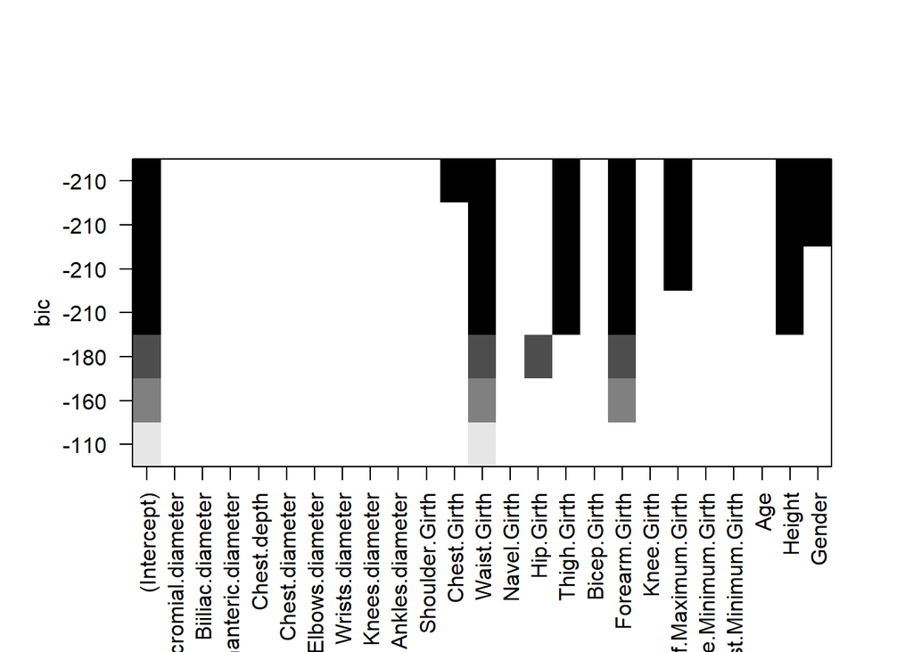

```r
#busqueda exhaustiva
# Evaluar todas las combinaciones de predictores
modelo_seleccion <- regsubsets(Weight ~ ., data = datos_exhaustivo,
                               nbest = 1, nvmax = 7, method = "exhaustive")

# Graficar selección de variables
plot(modelo_seleccion)
```

```r
# Resumen del modelo
resumen_modelo <- summary(modelo_seleccion)

# Índices del mejor modelo según BIC y R² ajustado
i_bic_min <- which.min(resumen_modelo$bic)
i_r2a_max <- which.max(resumen_modelo$adjr2)

# Subconjuntos óptimos
mejor_comb_bic <- resumen_modelo$which[i_bic_min, ]
mejor_comb_r2a <- resumen_modelo$which[i_r2a_max, ]

# Quitar Intercept
mejor_comb_bic <- mejor_comb_bic[names(mejor_comb_bic) != "(Intercept)"]
mejor_comb_r2a <- mejor_comb_r2a[names(mejor_comb_r2a) != "(Intercept)"]

# Nombres de variables seleccionadas
vars_bic <- names(mejor_comb_bic[mejor_comb_bic])
vars_r2a <- names(mejor_comb_r2a[mejor_comb_r2a])

# Quitar posibles variables dummy (si es necesario)
vars_bic <- unique(gsub("^(.*)\\d+$", "\\1", vars_bic))
vars_r2a <- unique(gsub("^(.*)\\d+$", "\\1", vars_r2a))

# Crear fórmulas
formula_bic <- as.formula(paste("Weight ~", paste(vars_bic, collapse = " + ")))
formula_r2a <- as.formula(paste("Weight ~", paste(vars_r2a, collapse = " + ")))

# Ajustar modelos
modelo_bic <- lm(formula_bic, data = datos_exhaustivo)
modelo_r2a <- lm(formula_r2a, data = datos_exhaustivo)

# Mostrar resumen de resultados
cat("Modelo que minimiza el BIC:\n")
```

```
## Modelo que minimiza el BIC:
```

```r
cat("----------------------------\n")
print(summary(modelo_bic))
```

```
##
## Call:
## lm(formula = formula_bic, data = datos_exhaustivo)
##
## Residuals:
##     Min      1Q  Median      3Q     Max
## -5.6522 -1.6899  0.0385  1.2269  4.2209
##
## Coefficients:
##                      Estimate Std. Error t value Pr(>|t|)
## (Intercept)        -109.85751    7.72642 -14.218  < 2e-16 ***
## Chest.Girth           0.15846    0.07254   2.185 0.032711 *
## Waist.Girth           0.45864    0.05624   8.155 2.13e-11 ***
## Thigh.Girth           0.39372    0.10580   3.721 0.000429 ***
## Forearm.Girth         1.36984    0.23357   5.865 1.88e-07 ***
## Calf.Maximum.Girth    0.54168    0.15497   3.495 0.000880 ***
## Height                0.30746    0.04171   7.371 4.89e-10 ***
## Gender               -2.92658    1.15811  -2.527 0.014068 *
## ---
## Signif. codes:  0 '***' 0.001 '**' 0.01 '*' 0.05 '.' 0.1 ' ' 1
##
## Residual standard error: 2.065 on 62 degrees of freedom
## Multiple R-squared:  0.971,  Adjusted R-squared:  0.9677
## F-statistic: 296.4 on 7 and 62 DF,  p-value: < 2.2e-16
```

```r
cat("\nModelo que maximiza el R² ajustado:\n")
```

```
##
## Modelo que maximiza el R² ajustado:
```

```r
cat("------------------------------------\n")
print(summary(modelo_r2a))
```

```
##
## Call:
## lm(formula = formula_r2a, data = datos_exhaustivo)
##
## Residuals:
##     Min      1Q  Median      3Q     Max
## -5.6522 -1.6899  0.0385  1.2269  4.2209
##
## Coefficients:
##                      Estimate Std. Error t value Pr(>|t|)
## (Intercept)        -109.85751    7.72642 -14.218  < 2e-16 ***
## Chest.Girth           0.15846    0.07254   2.185 0.032711 *
## Waist.Girth           0.45864    0.05624   8.155 2.13e-11 ***
## Thigh.Girth           0.39372    0.10580   3.721 0.000429 ***
## Forearm.Girth         1.36984    0.23357   5.865 1.88e-07 ***
## Calf.Maximum.Girth    0.54168    0.15497   3.495 0.000880 ***
## Height                0.30746    0.04171   7.371 4.89e-10 ***
## Gender               -2.92658    1.15811  -2.527 0.014068 *
## ---
## Signif. codes:  0 '***' 0.001 '**' 0.01 '*' 0.05 '.' 0.1 ' ' 1
##
## Residual standard error: 2.065 on 62 degrees of freedom
## Multiple R-squared:  0.971,  Adjusted R-squared:  0.9677
## F-statistic: 296.4 on 7 and 62 DF,  p-value: < 2.2e-16
```

Según los resultados de la búsqueda exhaustiva, se obtuvieron dos modelos: uno que minimiza el BIC y otro que maximiza el R² ajustado. En este caso, ambos coinciden, ya que seleccionan los mismos predictores: el grosor del pecho (Chest.Girth), el grosor de la cintura (Waist.Girth), el grosor promedio de los muslos (Thigh.Girth), el grosor promedio de los antebrazos (Forearm.Girth), el grosor promedio de las pantorrillas (Calf.Maximum.Girth), la estatura (Height) y el género (Gender).

De acuerdo con el resumen del modelo, todos los predictores son estadísticamente significativos, lo que indica que influyen en la variable de respuesta Weight (peso). Entre ellos, destacan especialmente el grosor de la cintura, el grosor de los muslos, antebrazos y pantorrillas, así como la estatura.

El modelo presenta un R² ajustado de 0.9677, lo que indica que el 96,77% de la variabilidad del peso puede explicarse por los predictores seleccionados, lo cual representa un muy buen ajuste. Además, el R² es de 0.971 (97,1%), lo que también refleja una alta capacidad explicativa. Por otro lado, el estadístico F es de 296.4 con un valor p de < 2.2e-16, lo que confirma que el modelo es significativo en su conjunto y que todos los predictores contribuyen de manera importante a explicar la variable dependiente.

se define el modelo con las variables predictores seleccionadas por la busqueda exhaustiva que fueron Chest.Girth, Thigh.Girth, Forearm.Girth, Calf.Maximum.Girth, Height y Gender, como variable de salida asignada fue Weight por enunciado, lo cual la formula a usar con la función lm() que contiene R es Weight ~ Chest.Girth + Waist.Girth + Thigh.Girth + Forearm.Girth + Calf.Maximum.Girth + Height + Gender con los datos de entrenamiento y retornando el resultado del modelo significativo anteriormente guardandolo en modelo_RLM_exhaustivo y mostrando su grafico

```r
modelo_RLM_exhaustivo <- lm(Weight ~ Chest.Girth + Waist.Girth + Thigh.Girth + Forearm.Girth + Calf.Maximum.Girth + Height + Gender, data = datos_exhaustivo)
summary(modelo_RLM_exhaustivo)
```

```
##
## Call:
## lm(formula = Weight ~ Chest.Girth + Waist.Girth + Thigh.Girth +
##     Forearm.Girth + Calf.Maximum.Girth + Height + Gender, data = datos_exhaustivo)
##
## Residuals:
##     Min      1Q  Median      3Q     Max
## -5.6522 -1.6899  0.0385  1.2269  4.2209
##
## Coefficients:
##                      Estimate Std. Error t value Pr(>|t|)
## (Intercept)        -109.85751    7.72642 -14.218  < 2e-16 ***
## Chest.Girth           0.15846    0.07254   2.185 0.032711 *
## Waist.Girth           0.45864    0.05624   8.155 2.13e-11 ***
## Thigh.Girth           0.39372    0.10580   3.721 0.000429 ***
## Forearm.Girth         1.36984    0.23357   5.865 1.88e-07 ***
## Calf.Maximum.Girth    0.54168    0.15497   3.495 0.000880 ***
## Height                0.30746    0.04171   7.371 4.89e-10 ***
## Gender               -2.92658    1.15811  -2.527 0.014068 *
## ---
## Signif. codes:  0 '***' 0.001 '**' 0.01 '*' 0.05 '.' 0.1 ' ' 1
##
## Residual standard error: 2.065 on 62 degrees of freedom
## Multiple R-squared:  0.971,  Adjusted R-squared:  0.9677
## F-statistic: 296.4 on 7 and 62 DF,  p-value: < 2.2e-16
```

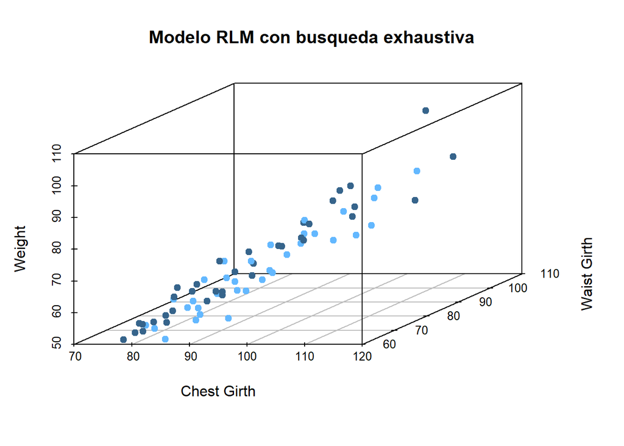

```r
i_color <- 1 + (resid(modelo_RLM_exhaustivo) > 0)

scatterplot3d(
  x = datos_exhaustivo$Chest.Girth,
  y = datos_exhaustivo$Waist.Girth,
  z = datos_exhaustivo$Weight,
  pch = 19,
  color = c("steelblue1", "steelblue4")[i_color],
  xlab = "Chest Girth",
  ylab = "Waist Girth",
  zlab = "Weight",
  main = "Modelo RLM con busqueda exhaustiva"
)
```

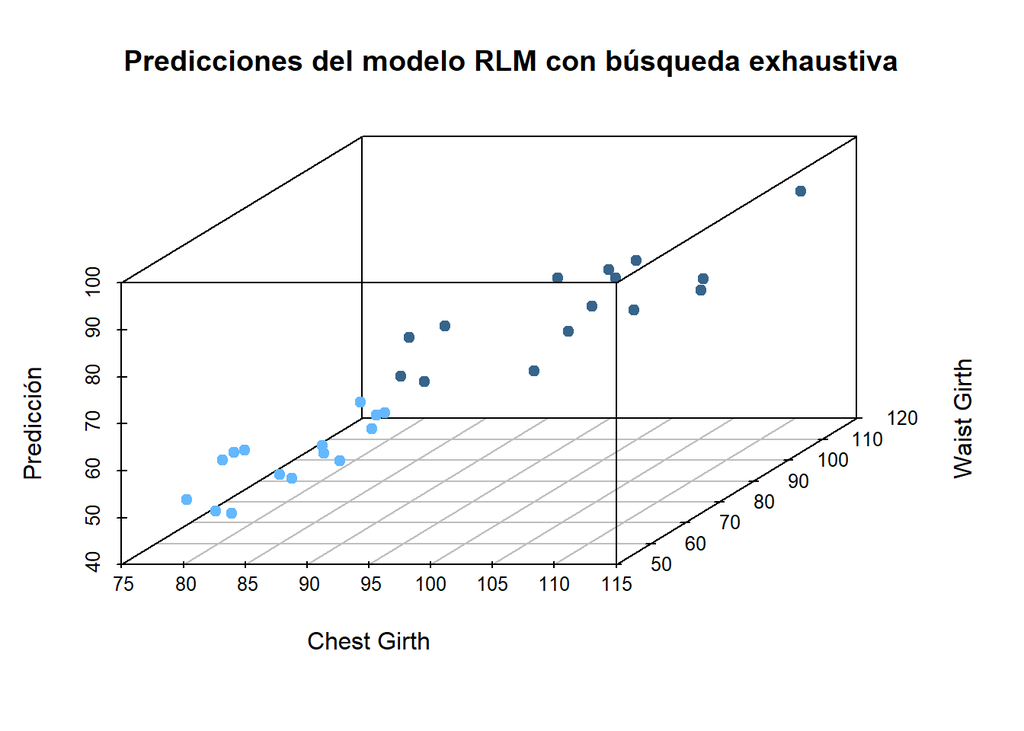

```r
nuevos <- c(1:30)

datos_nuevos <- data.frame(
  Chest.Girth = datos_pru$Chest.Girth,
  Waist.Girth = datos_pru$Waist.Girth,
  Thigh.Girth = datos_pru$Thigh.Girth,
  Forearm.Girth = datos_pru$Forearm.Girth,
  Calf.Maximum.Girth = datos_pru$Calf.Maximum.Girth,
  Height = datos_pru$Height,
  Gender = datos_pru$Gender
)

predicciones_RLM_exhaustivo <- predict(modelo_RLM_exhaustivo, newdata = datos_nuevos)
# Crear predicciones y añadirlas como columna con nombre
datos_nuevos$prediccion <- predict(modelo_RLM_exhaustivo, newdata = datos_nuevos)

# Crear índice de color según si la predicción es mayor que la media
i_color <- 1 + (datos_nuevos$prediccion > mean(datos_nuevos$prediccion))

# Graficar
scatterplot3d(
  x = datos_nuevos$Chest.Girth,
  y = datos_nuevos$Waist.Girth,
  z = datos_nuevos$prediccion,
  pch = 19,
  color = c("steelblue1", "steelblue4")[i_color],
  xlab = "Chest Girth",
  ylab = "Waist Girth",
  zlab = "Predicción",
  main = "Predicciones del modelo RLM con búsqueda exhaustiva"
)
```

```r
print(datos_nuevos)
```

```
##    Chest.Girth Waist.Girth Thigh.Girth Forearm.Girth Calf.Maximum.Girth Height
## 1        105.5        90.1        62.7          29.6               42.4  174.0
## 2         80.2        67.2        54.7          22.2               35.4  169.0
## 3        109.6        94.9        59.0          27.8               36.8  167.6
## 4         90.9        74.0        51.8          27.0               34.6  188.0
## 5        104.3        86.3        59.7          30.4               42.0  180.3
## 6         90.0        72.7        57.9          23.7               34.3  164.5
## 7        111.8        86.2        59.1          28.0               34.7  186.7
## 8         79.0        63.0        48.5          22.5               30.3  155.0
## 9         86.4        67.4        59.1          23.1               37.4  154.9
## 10        79.5        66.5        54.0          22.5               35.0  170.0
## 11       100.3        79.1        51.0          27.2               32.7  175.3
## 12        84.2        66.4        53.4          22.3               31.7  157.5
## 13        88.7        64.2        56.0          23.8               33.2  161.2
## 14        87.2        64.9        53.1          24.2               35.4  163.2
```

[output cut: 47 more lines]

La evaluación de los datos y los gráficos 3D tanto del modelo de entrenamiento como de las predicciones muestra una tendencia lineal creciente bien definida. Las predicciones generadas por el modelo de regresión lineal múltiple se alinean de manera adecuada con los datos reales, tanto desde el punto de vista estadístico como visual. Esto se respalda por el alto valor de R-cuadrado ajustado (0.9677), la significancia de los coeficientes y la baja dispersión de los residuos. En conjunto, estos resultados confirman que el modelo está bien ajustado.

1. La variable de respuesta debe ser cuantitativa y continua, sin restricciones para su variabilidad.

En el modelo de regresión lineal multiple con busqueda exhaustiva, la variable de respuesta es el peso, llamada “Weight”.

```r
str(datos_exhaustivo$Weight)
```

```
##  num [1:70] 61.4 68.2 61.4 72.3 59.8 50.2 93.2 62.3 55.9 82.7 ...
```

Se observa que la variable “Weight” es numérica y continua, por lo que cumple con la condición de que la variable de respuesta debe ser lo anteriormente mencionado.

2. Los predictores deben ser cuantitativos o dicotomicos.

Los predictores seleccionados en este modelo previamente son Chest.Girth, Waist.Girth, Thigh.Girt, Forearm.Girth, Calf.Maximum.Girth, Height y Gender, los cuales veremos a continuación sus datos.

```r
str(datos_exhaustivo$Chest.Girth)
```

```
##  num [1:70] 88 90.8 91.3 95.3 81.7 ...
```

```r
str(datos_exhaustivo$Waist.Girth)
```

```
##  num [1:70] 72 77.9 72.7 79.4 70 63.2 96 65.9 67.7 84 ...
```

```r
str(datos_exhaustivo$Thigh.Girth)
```

```
##  num [1:70] 57.3 56.2 51.2 63 57.9 52.1 62.2 57 54.3 57.6 ...
```

```r
str(datos_exhaustivo$Forearm.Girth)
```

```
##  num [1:70] 23.3 24.3 26 24.9 22.6 23.5 30.1 23.7 23.8 30.2 ...
```

```r
str(datos_exhaustivo$Calf.Maximum.Girth)
```

```
##  num [1:70] 31.9 36.6 34.7 36.3 36 31.6 39.4 34 32.7 38.2 ...
```

```r
str(datos_exhaustivo$Height)
```

```
##  num [1:70] 163 173 172 168 173 ...
```

```r
str(datos_exhaustivo$Gender)
```

```
##  int [1:70] 0 0 1 0 0 0 1 0 0 1 ...
```

Todos los predictores son cuantitativos o dicotómicos, por lo que cumplen con la condición de que los predictores deben ser cumplir dicha propiedad mencionada anteriormente.

3. Los predictores deben tener algun tipo de variabilidad (su varianza no debe ser igual a 0). En otras palabras no pueden ser constantes.

```r
apply(datos_exhaustivo[,c("Chest.Girth","Thigh.Girth", "Forearm.Girth", "Calf.Maximum.Girth", "Height", "Gender")], 2, var)
```

```
##        Chest.Girth        Thigh.Girth      Forearm.Girth Calf.Maximum.Girth
##         82.3152567         19.0626501          7.6016646          7.6285901
##             Height             Gender
##         67.4299565          0.2461698
```

Se observa que todos los predictores tienen una varianza distinta de 0, por lo que cumplen con la condición de que los predictores deben tener variabilidad.

4. Cada predictor debe estar relacionado linealmente con la respuesta.

Para verificar si cada predictor está relacionado linealmente con la respuesta, se puede observar el resumen del modelo de regresión lineal múltiple. En este caso, se analizarán los valores de los coeficientes y sus significancias.

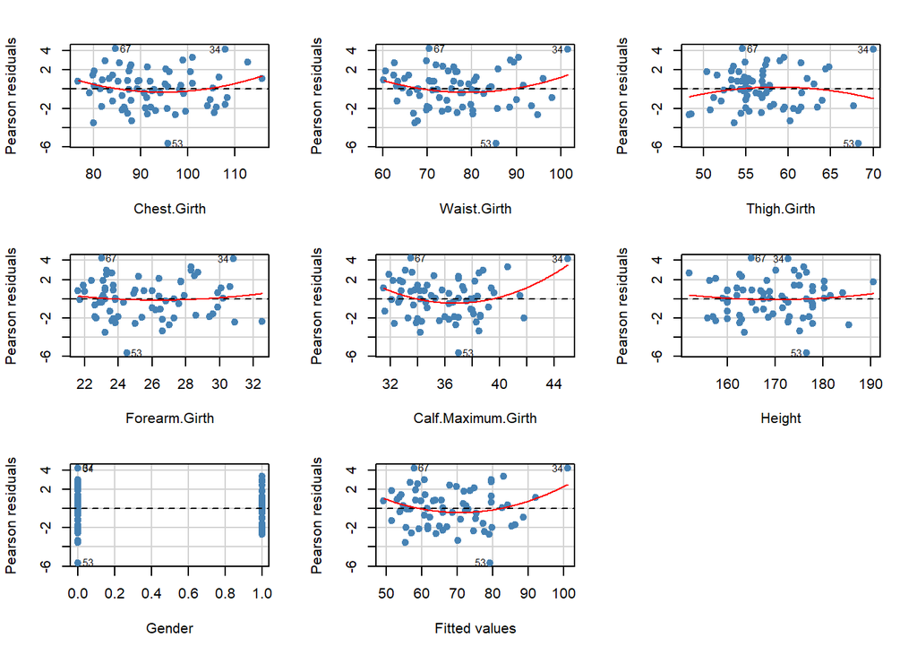

```
##                    Test stat Pr(>|Test stat|)
## Chest.Girth           1.4367          0.15591
## Waist.Girth           1.8005          0.07672 .
## Thigh.Girth          -1.1767          0.24390
## Forearm.Girth         0.6034          0.54850
## Calf.Maximum.Girth    2.7699          0.00742 **
## Height                0.4644          0.64400
## Gender               -0.8523          0.39740
## Tukey test            2.2135          0.02686 *
## ---
## Signif. codes:  0 '***' 0.001 '**' 0.01 '*' 0.05 '.' 0.1 ' ' 1
```

```r
residualPlots(modelo_RLM_exhaustivo, sd = TRUE, terms =  ~ Chest.Girth + Waist.Girth + Thigh.Girth + Forearm.Girth + Calf.Maximum.Girth + Height + Gender, id = list(method = "r", n = 3, cex = 0.7, location = "lr"), col = "steelblue", pch = 19, col.quad= "red")
```

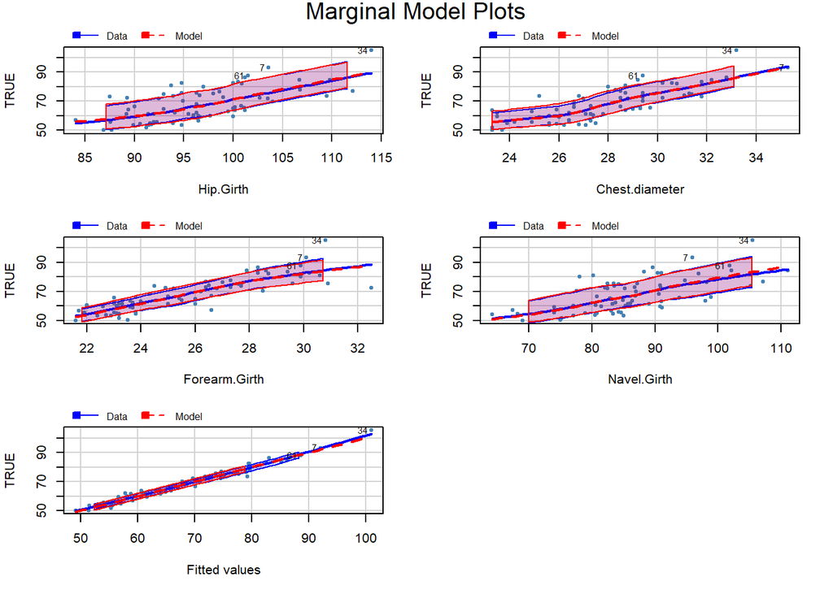

```r
marginalModelPlots(modelo_RLM_exhaustivo, sd = TRUE, terms =  ~ Hip.Girth + Chest.diameter + Forearm.Girth + Navel.Girth, id = list(method = "r", n = 3, cex = 0.7, location = "lr"), col = "steelblue", pch = 20, col.quad= c("steelblue", "red"))
```

6. La variabilidad de los residuos deben ser aproximadamente constantes (homocedasticidad).

Para este caso se usa la función nvcTest() sobre los datos del modelo RLM exhaustivo para comprobar que se cumple esta condición.

```r
ncvTest(modelo_RLM_exhaustivo)
```

```
## Non-constant Variance Score Test
## Variance formula: ~ fitted.values
## Chisquare = 3.11014, Df = 1, p = 0.077806
```

El valor p = 0.077806 es mayor que el nivel de significancia α = 0.05, por lo que no se rechaza la hipótesis nula. Esto indica que se cumple el supuesto de homocedasticidad, confirmando que la variabilidad de los residuos es aproximadamente constante.

7. Los residuos deben ser independientes entre si.

Se utiliza el metodo de Durbin-Watson para comprobar si los residuos son independiente entre si utilizando la funcion en R llamada durbinwatsonTest().

```r
durbinWatsonTest(modelo_RLM_exhaustivo)
```

```
##  lag Autocorrelation D-W Statistic p-value
##    1      0.04623146      1.841227   0.546
##  Alternative hypothesis: rho != 0
```

8. No debe existir multicolinealidad entre los predictores.

Se utiliza la función vif() de R para comprobar que no exista multicolinealidad entre los predictores.

```r
vif(modelo_RLM_exhaustivo)
```

```
##        Chest.Girth        Waist.Girth        Thigh.Girth      Forearm.Girth
##           7.007550           4.851589           3.452452           6.709541
## Calf.Maximum.Girth             Height             Gender
##           2.963975           1.898260           5.341773
```

9. Las estimaciones de los coeficientes del modelo no deben estar alterados por unas pocas observaciones influyentes.

Para esta condición se usa la función influencePlot() para ver si hay residuos influyentes.

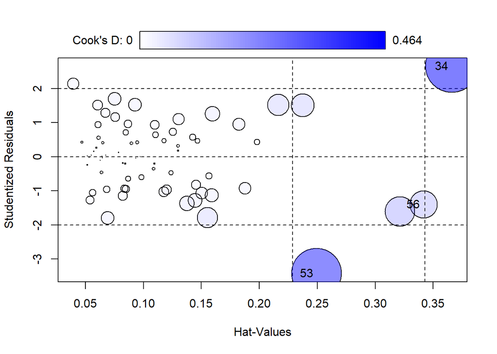

```
##      StudRes       Hat     CookD
## 34  2.654496 0.3661145 0.4635187
## 53 -3.421077 0.2494588 0.4146625
## 56 -1.399281 0.3414413 0.1249632
```

```r
influencePlot(modelo_RLM_exhaustivo, id.method = "identify")
```

Segun el grafico burbuja, no se presenta un D mayoro o igual a 1, lo que significa que no hay puntos influyentes en las observaciones del modelo que esten afectandolo.

Para la calidad predictiva se utilizará la función train() para hacer validación cruzada pero usando el metodo de bootstraping mencionada en el enunciado para ver su calidad predictiva.

```r
ent <- train(
  Weight ~ Chest.Girth + Waist.Girth + Thigh.Girth + Forearm.Girth + Calf.Maximum.Girth + Height + Gender,
  data = datos_exhaustivo,
  method = "lm",
  trControl = trainControl(method = "boot", number = 5)
)

modelofRLM <- ent[["finalModel"]]
print(summary(modelofRLM))
```

```
##
## Call:
## lm(formula = .outcome ~ ., data = dat)
##
## Residuals:
##     Min      1Q  Median      3Q     Max
## -5.6522 -1.6899  0.0385  1.2269  4.2209
##
## Coefficients:
##                      Estimate Std. Error t value Pr(>|t|)
## (Intercept)        -109.85751    7.72642 -14.218  < 2e-16 ***
## Chest.Girth           0.15846    0.07254   2.185 0.032711 *
## Waist.Girth           0.45864    0.05624   8.155 2.13e-11 ***
## Thigh.Girth           0.39372    0.10580   3.721 0.000429 ***
## Forearm.Girth         1.36984    0.23357   5.865 1.88e-07 ***
## Calf.Maximum.Girth    0.54168    0.15497   3.495 0.000880 ***
## Height                0.30746    0.04171   7.371 4.89e-10 ***
## Gender               -2.92658    1.15811  -2.527 0.014068 *
## ---
## Signif. codes:  0 '***' 0.001 '**' 0.01 '*' 0.05 '.' 0.1 ' ' 1
##
## Residual standard error: 2.065 on 62 degrees of freedom
## Multiple R-squared:  0.971,  Adjusted R-squared:  0.9677
## F-statistic: 296.4 on 7 and 62 DF,  p-value: < 2.2e-16
```

```r
print(ent[["resample"]])
```

```
##       RMSE  Rsquared      MAE  Resample
## 1 3.471370 0.9335438 2.572146 Resample1
## 2 2.355917 0.9507361 1.878321 Resample2
## 3 2.275401 0.9643252 1.820892 Resample3
## 4 2.370104 0.9239202 2.051944 Resample4
## 5 2.306680 0.9607086 1.894166 Resample5
```

```r
print(ent[["results"]])
```

```
##   intercept     RMSE  Rsquared      MAE    RMSESD RsquaredSD     MAESD
## 1      TRUE 2.555894 0.9466468 2.043494 0.5131736 0.01742965 0.3076839
```

#RLM CON RFE

```r
library(caret)
set.seed(21003)

# Crear el dataframe con predictores y respuesta
datos_RFE <- datos_ent %>%
  ungroup() %>%
  select(-Weight, -Height, -EN)

# Crear fórmula correctamente
rlm_fmla <- formula(paste("IMC", "~", "."))

# Definir control para RFE
ctrl <- rfeControl(
  functions = lmFuncs,
  method = "repeatedcv",
  repeats = 5,
  number = 5,
  verbose = FALSE
)

# Ejecutar RFE
set.seed(21003)
resultado_rfe <- rfe(
  rlm_fmla,
  data = datos_RFE,
  rfeControl = ctrl,
  sizes = 10:20,
  metric = "Rsquared"
)

# Obtener modelo final
modelo_rfe <- resultado_rfe$fit
print(modelo_rfe)
```

```
##
## Call:
## lm(formula = y ~ ., data = tmp)
##
## Coefficients:
##         (Intercept)               Gender      Wrists.diameter
##           -10.79572             -1.54508             -0.27654
## Wrist.Minimum.Girth          Thigh.Girth        Forearm.Girth
##             0.46990              0.33953              0.23713
##     Elbows.diameter       Chest.diameter          Bicep.Girth
##             0.10243              0.14534              0.07287
##          Knee.Girth          Waist.Girth     Biiliac.diameter
##            -0.20078              0.17567             -0.20755
##     Ankles.diameter
##            -0.22372
```

Se obtiene entonces que los predictores que construyen el modelo corresponden a:

```r
predictores <- resultado_rfe$optVariables
cat("Los predictores seleccionados son:", paste(predictores, collapse = ", "), "\n")
```

```
## Los predictores seleccionados son: Gender, Wrists.diameter, Wrist.Minimum.Girth, Thigh.Girth, Forearm.Girth, Elbows.diameter, Chest.diameter, Bicep.Girth, Knee.Girth, Waist.Girth, Biiliac.diameter, Ankles.diameter
```

```r
# Crear la fórmula para el modelo
fmla_rfe <- as.formula(paste("IMC ~", paste(predictores, collapse = " + ")))

# Ajustar el modelo final
modelo_final <- lm(fmla_rfe, data = datos_RFE)
print(modelo_final)
```

```
##
## Call:
## lm(formula = fmla_rfe, data = datos_RFE)
##
## Coefficients:
##         (Intercept)               Gender      Wrists.diameter
##           -10.79572             -1.54508             -0.27654
## Wrist.Minimum.Girth          Thigh.Girth        Forearm.Girth
##             0.46990              0.33953              0.23713
##     Elbows.diameter       Chest.diameter          Bicep.Girth
##             0.10243              0.14534              0.07287
##          Knee.Girth          Waist.Girth     Biiliac.diameter
##            -0.20078              0.17567             -0.20755
##     Ankles.diameter
##            -0.22372
```

Para analizar la confiabilidad de este modelo se deben verificar las siguientes condiciones:

1. *La variable de respuesta debe ser cuantitativa y continua, sin restricciones para su variabilidad.*

Esto se cumple ya que la variable de respuesta corresponde al IMC, esta al ser un cálculo de peso y altura, es continua y cuantitativa.

2. *Los predictores deben ser cuantitativos o dicotomicos.* Esta condición se cumple ya que todos las variables corresponden a datos cuantitativos, a excepción del dato *gender* que es dicotómico, cumpliendo de igual manera con la condición.
3. *Los predictores deben tener algún grado de variabilidad, no pueden ser constantes.*

Para comprobar esta condición se debe calcular la varianza de cada uno de los predictores, obtieniedo que:

```r
var(datos_RFE$Gender)
```

```
## [1] 0.2461698
```

```r
var(datos_RFE$Wrist.Minimum.Girth)
```

```
## [1] 1.764151
```

```r
var(datos_RFE$Wrists.diameter)
```

```
## [1] 1.001054
```

```r
var(datos_RFE$Thigh.Girth)
```

```
## [1] 19.06265
```

```r
var(datos_RFE$Forearm.Girth)
```

```
## [1] 7.601665
```

```r
var(datos_RFE$Elbows.diameter)
```

```
## [1] 1.572638
```

```r
var(datos_RFE$Chest.Girth)
```

```
## [1] 82.31526
```

```r
var(datos_RFE$Knee.Girth)
```

```
## [1] 6.378476
```

```r
var(datos_RFE$Bicep.Girth)
```

```
## [1] 17.14521
```

```r
var(datos_RFE$Waist.Girth)
```

```
## [1] 94.7979
```

```r
var(datos_RFE$Biiliac.diameter)
```

```
## [1] 3.909112
```

```r
var(datos_RFE$Ankles.diameter)
```

```
## [1] 1.447172
```

Vemos entonces como estos resultados cumplen con tener algún grado de variabilidad.

Para verificar las condiciones de la 4 a la 6, se analizará a partir de los siguientes gráficos:

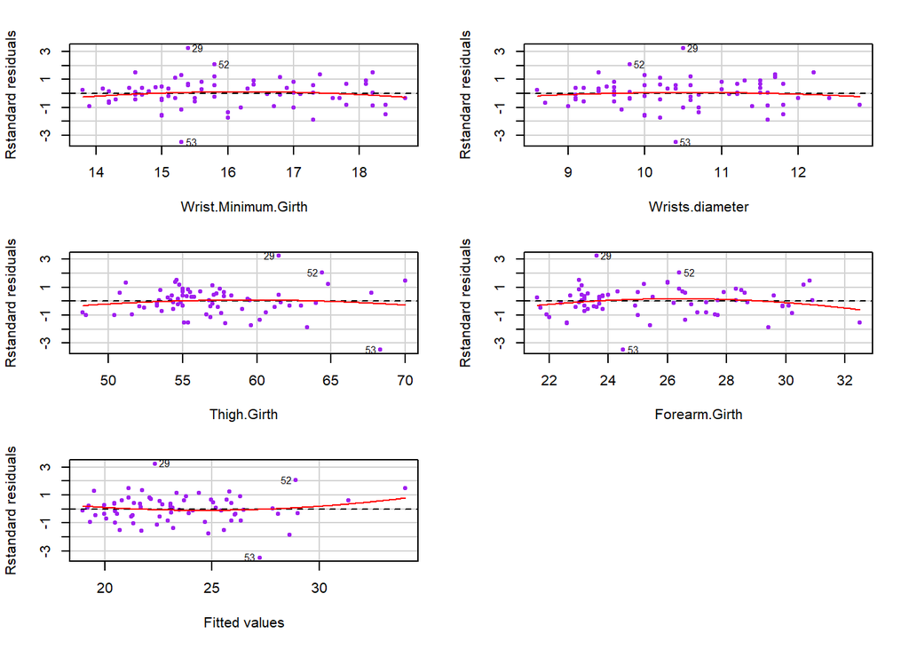

```
##                     Test stat Pr(>|Test stat|)
## Wrist.Minimum.Girth   -0.7603           0.4502
## Wrists.diameter       -0.4543           0.6514
## Thigh.Girth           -0.9399           0.3513
## Forearm.Girth         -1.2938           0.2011
## Tukey test             0.9876           0.3233
```

```r
# Cargar librería
library(car)

# Bloque 1: primeros 5 predictores
residualPlots(
  modelo_final,
  type = "rstandard",
  terms = ~ Wrist.Minimum.Girth + Wrists.diameter + Thigh.Girth + Forearm.Girth,
  id = list(method = "r", n = 3, cex = 0.7, location = "lr"),
  col = "purple", pch = 20, col.quad = "red"
)
```

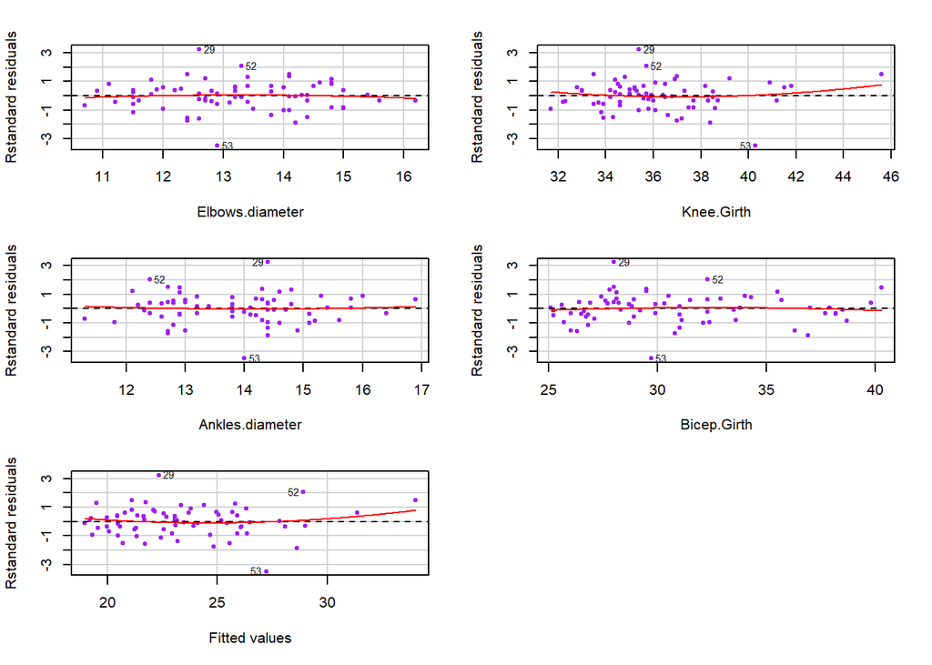

```
##                 Test stat Pr(>|Test stat|)
## Elbows.diameter   -0.3367           0.7376
## Knee.Girth         0.8455           0.4014
## Ankles.diameter    0.3283           0.7439
## Bicep.Girth       -0.5914           0.5567
## Tukey test         0.9876           0.3233
```

```r
# Bloque 2: predictores restantes
residualPlots(
  modelo_final,
  type = "rstandard",
  terms = ~ Elbows.diameter + Knee.Girth + Ankles.diameter + Bicep.Girth,
  id = list(method = "r", n = 3, cex = 0.7, location = "lr"),
  col = "purple", pch = 20, col.quad = "red"
)
```

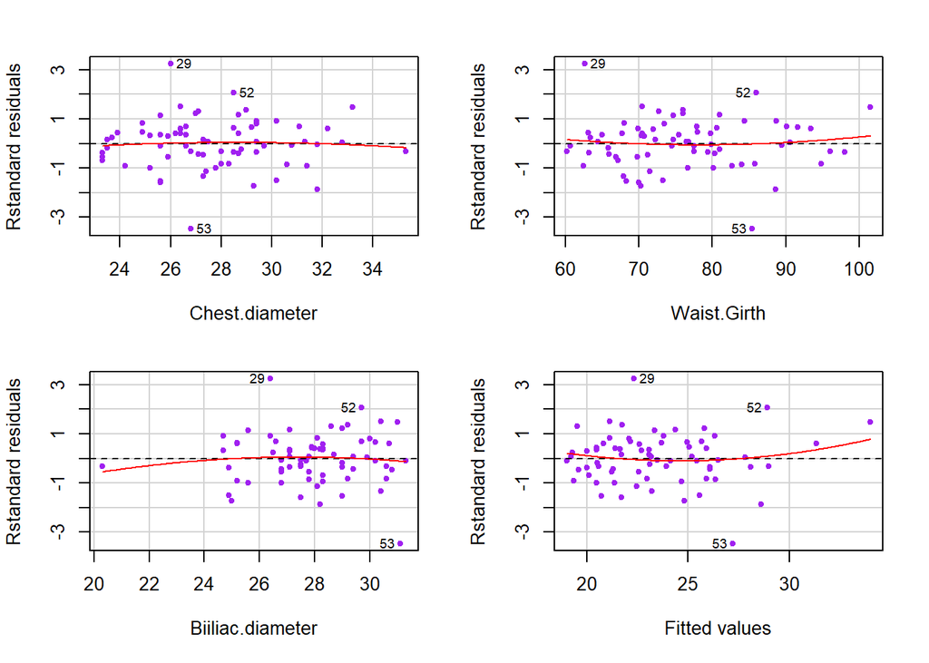

```
##                  Test stat Pr(>|Test stat|)
## Chest.diameter     -0.4270           0.6710
## Waist.Girth         0.5046           0.6158
## Biiliac.diameter   -0.7044           0.4841
## Tukey test          0.9876           0.3233
```

```r
residualPlots(
  modelo_final,
  type = "rstandard",
  terms = ~ Chest.diameter + Waist.Girth + Biiliac.diameter,
  id = list(method = "r", n = 3, cex = 0.7, location = "lr"),
  col = "purple", pch = 20, col.quad = "red"
)
```

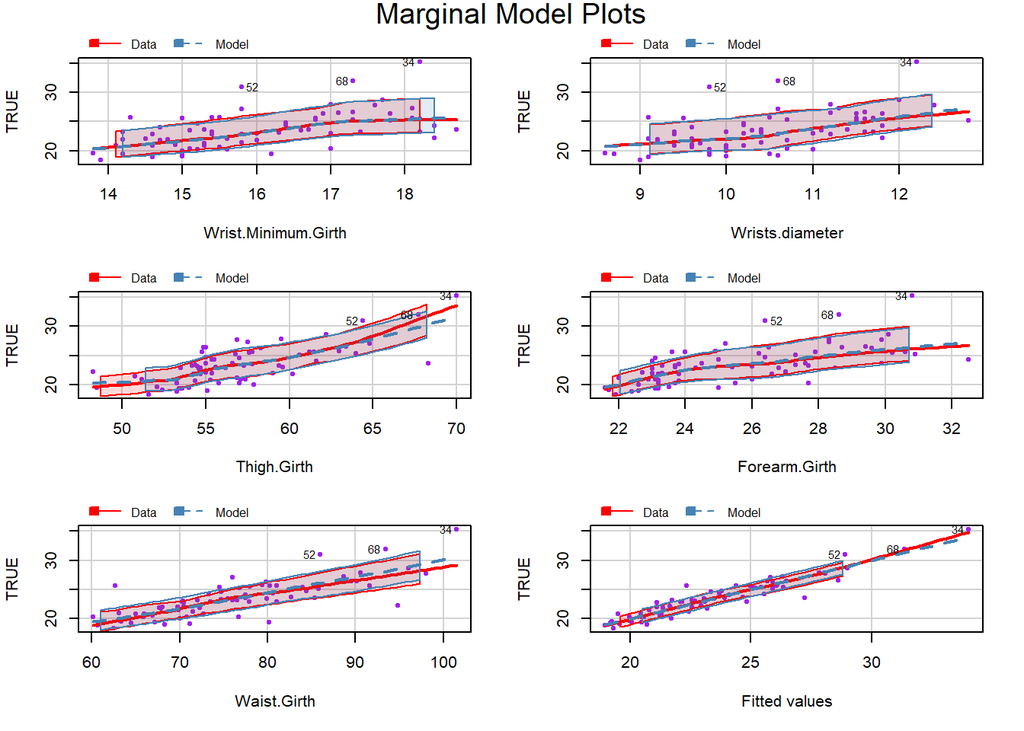

```r
# Gráficos marginales: relación entre predictores y la variable respuesta (IMC)
# Bloque 1
marginalModelPlots(
  modelo_final,
  sd = TRUE,
  terms = ~  Wrist.Minimum.Girth + Wrists.diameter + Thigh.Girth + Forearm.Girth + Waist.Girth,
  id = list(method = "r", n = 3, cex = 0.7, location = "lr"),
  col = "purple", pch = 20, col.line = c("red", "steelblue")
)
```

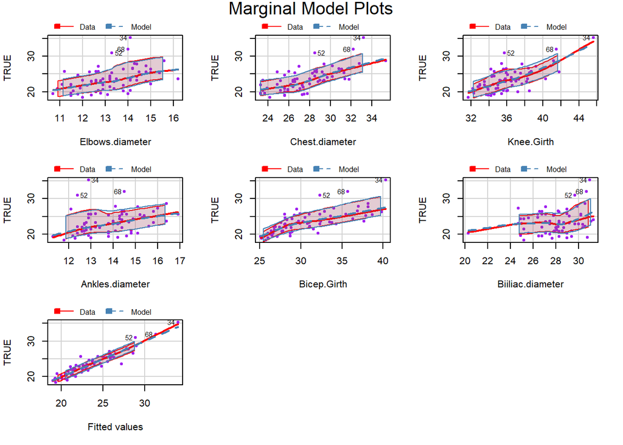

```r
# Bloque 2
marginalModelPlots(
  modelo_final,
  sd = TRUE,
  terms = ~ Elbows.diameter + Chest.diameter + Knee.Girth + Ankles.diameter + Bicep.Girth + Biiliac.diameter,
  id = list(method = "r", n = 3, cex = 0.7, location = "lr"),
  col = "purple", pch = 20, col.line = c("red", "steelblue")
)
```

4. *Cada predictor debe estar relacionado linealmente con la respuesta.*

Para esta condición, al revisar el gráfico de residuos se puede notar que las 11 variables mantienen en su mayoría una relación lineal con la variable de respuesta, algunas variables presentan una leve curvatura en sus extremos pero no es lo suficientemente significativa como para considerar que no cumplen con la condición.

5. *La distribución de los residuos debe ser cercana a la normal centrada en cero.*

Al realizar el análisis de los gráficos se puede observar que la mayoría de los residuos se centran alrededor del valor cero, aunque algunos presentan una ligera desviación hacia la derecha, lo que indica que la distribución de los residuos no es completamente normal. Sin embargo, la mayoría de los residuos se concentran en torno a cero, lo que sugiere que la condición se cumple en gran medida.

6. *La variabilidad de los residuos debe ser aproximadamente constante(homocedasticidad).*

```r
ncvTest(modelo_final)
```

```
## Non-constant Variance Score Test
## Variance formula: ~ fitted.values
## Chisquare = 3.227024, Df = 1, p = 0.072432
```

7. *Los residuos deben ser independientes entre sí.*

Para verificar la independencia de los residuos, se puede utilizar el test de Durbin-Watson, obteniendo los siguientes resultados:

```r
durbinWatsonTest(modelo_final)
```

```
##  lag Autocorrelation D-W Statistic p-value
##    1      -0.1168047      2.228152   0.316
##  Alternative hypothesis: rho != 0
```

Con estos resultados se puede descartar que exista autocorrelación entre los residuos, por lo que no hay evidencia de que no se cumpla la condición de independencia.

8. *No debe existir multicolinealidad. No deben darse relaciones lineales fuertes entre 2 o más predictores.*

Para verificar la multicolinealidad se puede utilizar el VIF (Variance Inflation Factor), obteniendo los siguientes resultados:

```r
vif(modelo_final)
```

```
##              Gender     Wrists.diameter Wrist.Minimum.Girth         Thigh.Girth
##            6.575192            6.750670            9.253304            3.480696
##       Forearm.Girth     Elbows.diameter      Chest.diameter         Bicep.Girth
##           16.055325            8.316570            3.214717           12.190169
##          Knee.Girth         Waist.Girth    Biiliac.diameter     Ankles.diameter
##            3.539701            4.807171            1.598518            4.235107
```

Los predictores Thigh.Girth, Chest.diameter, Waist.Girth, Biiliac.diameter, Knee.Girth y Ankles.diameter presentan un VIF entre 1 y 5, lo que quiere decir que existe multicolinealidad moderada la cual podría llegar a afectar ligeramente los resultados, pero esto no llega a ser preocupante. Los demás predictores tienen un entre 5 y 10, que presentan una multicolinealidad preocupantes y esto podría afectar los resultados del modelo, por lo que se deberían considerar acciones correctivas. Por último y muy relevante las variables Forearm.Girth y Bicep.Girth presentan un VIF mayor a 10, lo que indica una multicolinealidad severa, por lo que es probable que los coeficientes sean inestables y las inferencias estadísticas sean poco fiables.

```r
modelo_sin_forearm <- update(modelo_final, . ~ . - Forearm.Girth)
vif(modelo_sin_forearm)
```

```
##              Gender     Wrists.diameter Wrist.Minimum.Girth         Thigh.Girth
##            5.424834            6.745591            8.256745            3.423069
##     Elbows.diameter      Chest.diameter         Bicep.Girth          Knee.Girth
##            8.205739            3.214193            5.966406            3.412238
##         Waist.Girth    Biiliac.diameter     Ankles.diameter
##            4.206350            1.590476            4.142274
```

Se puede notar como al eliminar la variable más problemática el problema parece mejorar, de modo que de todos modos se presentae una multicolinealidad preocupantes y esto *podría* afectar los resultados del modelo, veamos entonces que:

```r
modelo_2<- update(modelo_sin_forearm, . ~ . - Wrist.Minimum.Girth)
vif(modelo_2)
```

```
##           Gender  Wrists.diameter      Thigh.Girth  Elbows.diameter
##         5.422153         5.194565         3.311268         8.168553
##   Chest.diameter      Bicep.Girth       Knee.Girth      Waist.Girth
##         3.194909         5.477560         3.077709         4.201742
## Biiliac.diameter  Ankles.diameter
##         1.539404         4.077558
```

Este modelo presenta una gran mejora en cuanto a la multicolinealidad, sin embargo el valor Elbows.diameter sigue siendo problemático, por lo que se puede seguir eliminando variables problemáticas hasta llegar a un modelo aceptable.

```r
modelo_3 <- update(modelo_2, . ~ . - Elbows.diameter)
vif(modelo_3)
```

```
##           Gender  Wrists.diameter      Thigh.Girth   Chest.diameter
##         5.302678         4.437654         3.268547         3.179574
##      Bicep.Girth       Knee.Girth      Waist.Girth Biiliac.diameter
##         4.286776         3.022570         4.029746         1.388444
##  Ankles.diameter
##         3.126806
```

9. *Las estimaciones de los coeficientes del modelo no deben estar alterados por unos pocos observaciones influyentes.*

Para esta condición se quiere obtener una representación de posibles valores atípicos, el apalancamiento y distancia de Cook de los residuos generados por el modelo a través de la función influencePlot, obteniendo los siguientes resultados:

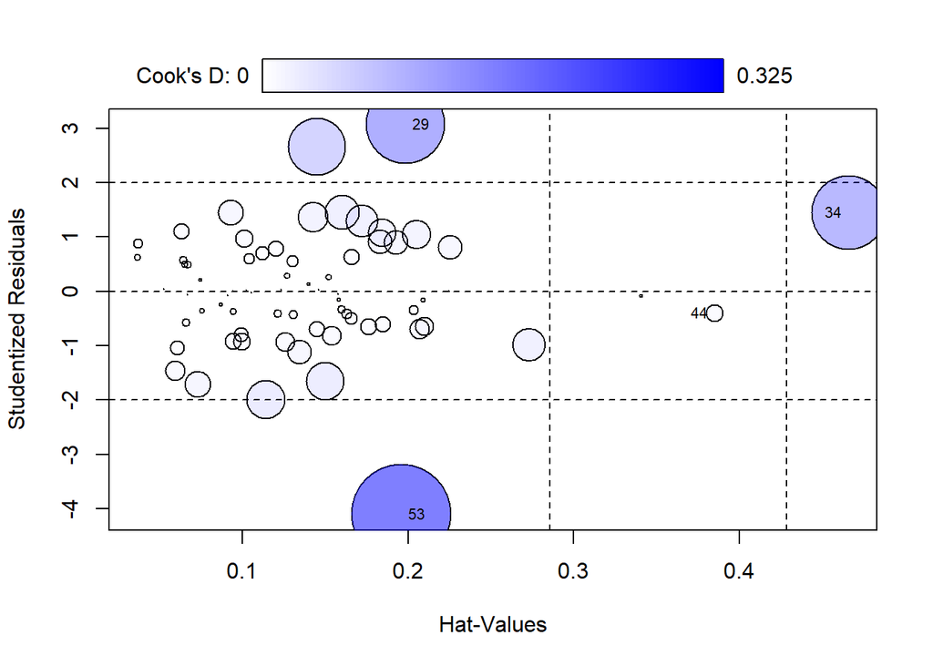

```
##       StudRes       Hat      CookD
## 29  3.0651732 0.1985462 0.20418237
## 34  1.4473021 0.4659106 0.17945467
## 44 -0.3988384 0.3848683 0.01009411
## 53 -4.1031701 0.1959594 0.32464069
```

```r
influencePlot(modelo_3, id = list(cex = 0.7))
```

Para la calidad predictiva del modelo de regresión lineal múltiple con RFE, veamos que:

```r
library(caret)

# Crear fórmula sin los predictores eliminados
fmla_modelo3 <- IMC ~ Wrists.diameter + Thigh.Girth + Chest.Girth + Knee.Girth +
                 Bicep.Girth + Waist.Girth + Biiliac.diameter + Ankles.diameter + Gender

# Definir control de validación cruzada LOOCV
ctrl_loocv <- trainControl(method = "LOOCV")

# Ajustar el modelo usando train con LOOCV
set.seed(21003)
entrenamiento_modelo3 <- train(
  fmla_modelo3,
  data = datos_RFE,
  method = "lm",
  trControl = ctrl_loocv
)

# Extraer el modelo ajustado
modelo3 <- entrenamiento_modelo3[["finalModel"]]

# Mostrar fórmula del modelo
cat("Modelo ajustado con LOOCV:\n")
```

```
## Modelo ajustado con LOOCV:
```

```r
cat("----------------------------------------------------------\n")
print(fmla_modelo3)
```

```
## IMC ~ Wrists.diameter + Thigh.Girth + Chest.Girth + Knee.Girth +
##     Bicep.Girth + Waist.Girth + Biiliac.diameter + Ankles.diameter +
##     Gender
```

```r
cat("\n")
```

```r
# Mostrar predicciones en cada pliegue
cat("Predicciones en cada pliegue:\n")
```

```
## Predicciones en cada pliegue:
```

```r
print(entrenamiento_modelo3[["pred"]])
```

```
##        pred      obs rowIndex intercept
## 1  22.40818 23.22348        1      TRUE
## 2  22.57996 22.86650        2      TRUE
## 3  19.05558 20.87566        3      TRUE
## 4  25.52729 25.73892        4      TRUE
## 5  22.07292 19.98062        5      TRUE
## 6  19.87361 19.60937        6      TRUE
## 7  28.94559 28.66979        7      TRUE
## 8  20.75745 20.29644        8      TRUE
## 9  20.99313 21.83594        9      TRUE
## 10 26.47816 25.43982       10      TRUE
## 11 25.41342 27.09925       11      TRUE
## 12 24.25988 23.60768       12      TRUE
## 13 24.47116 22.96401       13      TRUE
## 14 20.53142 19.42249       14      TRUE
```

[output cut: 56 more lines]

```r
# Mostrar error estimado para el modelo
cat("\nError estimado para el modelo:\n")
```

```
##
## Error estimado para el modelo:
```

```r
print(entrenamiento_modelo3[["results"]])
```

```
##   intercept     RMSE  Rsquared     MAE
## 1      TRUE 1.347846 0.8247166 1.01373
```

# RLOG con ROC

```r
set.seed(21003)

# Eliminamos IMC, Weight y Height
datos_ROC <- datos_ent %>%
  ungroup() %>%
  select(-IMC, -Weight, -Height)

x <- datos_ROC %>%
  select(-EN)

# RFE con  validación cruzada
ctrl_ROC <- rfeControl(
  functions = lrFuncs,
  method = "LOOCV",
  verbose = FALSE
)

# RFE para seleccionar entre 2 y 6 predictores
resultado_rfe <- rfe(
   x = x,
   y = datos_ROC$EN,
   sizes = c(2:6),
   rfeControl = ctrl_ROC
)


modelo_RLOG <- resultado_rfe$fit
print(summary(modelo_RLOG))
```

```
##
## Call:
## glm(formula = Class ~ ., family = "binomial", data = tmp)
##
## Coefficients:
##                 Estimate Std. Error z value Pr(>|z|)
## (Intercept)    -84.83771   25.77359  -3.292 0.000996 ***
## Thigh.Girth      0.93410    0.30670   3.046 0.002321 **
## Chest.depth     -0.69107    0.51896  -1.332 0.182984
## Waist.Girth      0.41677    0.14891   2.799 0.005130 **
## Shoulder.Girth   0.12793    0.06753   1.894 0.058159 .
## ---
## Signif. codes:  0 '***' 0.001 '**' 0.01 '*' 0.05 '.' 0.1 ' ' 1
##
## (Dispersion parameter for binomial family taken to be 1)
##
##     Null deviance: 97.041  on 69  degrees of freedom
## Residual deviance: 28.000  on 65  degrees of freedom
## AIC: 38
##
## Number of Fisher Scoring iterations: 8
```

```r
set.seed(21003)
library(pROC)
```

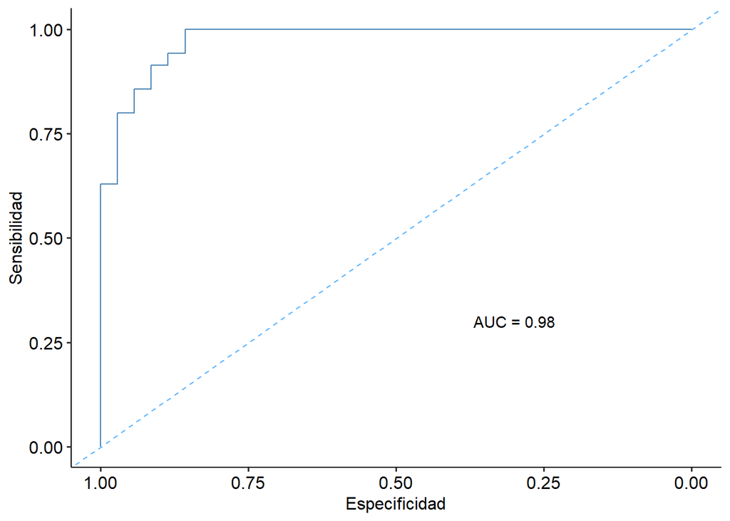

```r
library(ggplot2)
library(ggpubr)

# Comprobar la calidad del modelo con ROC
probs_RLOG <- predict(modelo_RLOG, type = "response")
datos_ROC$EN <- factor(datos_ROC$EN, levels = c("No_sobrepeso", "Sobrepeso"))
ROC_rlog <- roc(datos_ROC$EN, probs_RLOG,
                levels = c("No_sobrepeso", "Sobrepeso"), direction = "<")

g_ROC_rlog <- ggroc(ROC_rlog, color = "steelblue")

g_ROC_rlog <- g_ROC_rlog +
  geom_abline(intercept = 1, slope = 1, colour = "steelblue1", linetype = "dashed")
texto_auc <- sprintf("AUC = %.2f", ROC_rlog[["auc"]])

g_ROC_rlog <- g_ROC_rlog +
  xlab("Especificidad") +
  ylab("Sensibilidad") +
  annotate("text", x = 0.3, y = 0.3, label = texto_auc)

g_ROC_rlog <- g_ROC_rlog + theme_pubr()


print(g_ROC_rlog)
```

```r
set.seed(21003)
library(caret)

# Predecir clases usando un umbral de 0.5
clase_predicha <- ifelse(probs_RLOG >= 0.5, "Sobrepeso", "No_sobrepeso")
clase_predicha <- factor(clase_predicha, levels = c("No_sobrepeso", "Sobrepeso"))

# Asegurar que las clases reales están bien codificadas
datos_ROC$EN <- factor(datos_ROC$EN, levels = c("No_sobrepeso", "Sobrepeso"))

# Construir matriz de confusión
matriz_confusion <- confusionMatrix(clase_predicha, datos_ROC$EN)

# Mostrar resultados
print(matriz_confusion)
```

```
## Confusion Matrix and Statistics
##
##               Reference
## Prediction     No_sobrepeso Sobrepeso
##   No_sobrepeso           31         3
##   Sobrepeso               4        32
##
##                Accuracy : 0.9
##                  95% CI : (0.8048, 0.9588)
##     No Information Rate : 0.5
##     P-Value [Acc > NIR] : 1.138e-12
##
##                   Kappa : 0.8
##
##  Mcnemar's Test P-Value : 1
##
##             Sensitivity : 0.8857
##             Specificity : 0.9143
##          Pos Pred Value : 0.9118
##          Neg Pred Value : 0.8889
##              Prevalence : 0.5000
##          Detection Rate : 0.4429
##    Detection Prevalence : 0.4857
##       Balanced Accuracy : 0.9000
##
##        'Positive' Class : No_sobrepeso
##
```

Podemos decir que el modelo de regresión logística alcanza una precisión del 90% en clasificar correctamente las observaciones. Esto indica que el modelo es altamente efectivo para predecir el estado nutricional (sobrepeso o no sobrepeso) basado en las variables seleccionadas.

# CONFIABILIDAD Y CALIDAD PREDICTIVA DE LOS MODELOS

- Modelo RLOG

Antes de empezar, comprobaremos la multicolinealidad para primero encontrar variables no deseadas a causa de la colinealidad.

```r
set.seed(21003)
library(car)

vars_seleccionadas <- predictors(resultado_rfe)
formula_RLOG <- as.formula(paste("EN ~", paste(vars_seleccionadas, collapse = " + ")))

# Ajustar nuevamente el modelo usando datos_ROC
modelo_RLOG_glm <- glm(formula_RLOG, data = datos_ROC, family = binomial)

# Comprobar multicolinealidad

# Vif
vif(modelo_RLOG_glm)
```

```
##    Thigh.Girth    Chest.depth    Waist.Girth Shoulder.Girth
##       3.320631       2.986969       5.382010       1.553116
```

```r
# Tolerancia
print(1 / vif(modelo_RLOG_glm))
```

```
##    Thigh.Girth    Chest.depth    Waist.Girth Shoulder.Girth
##      0.3011476      0.3347875      0.1858042      0.6438669
```

Podemos ver que Waist.Girth tiene un VIF de 5.38, aunque ligeramente mayor a 5, indica una colinealidad moderada. Por lo tanto, eliminaremos Waist.Girth del modelo para evitar problemas de multicolinealidad.

1. Debe existir una relación lineal entre los predictores y la respuesta transformada:

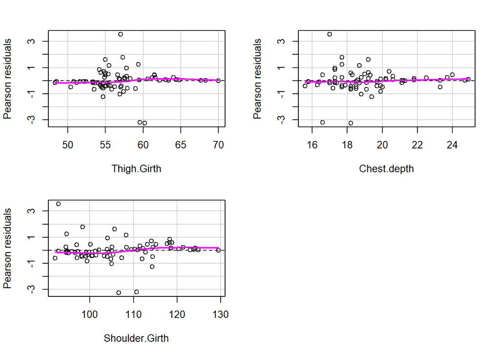

```
##                Test stat Pr(>|Test stat|)
## Thigh.Girth       0.3511          0.55350
## Chest.depth       0.0433          0.83515
## Shoulder.Girth    4.8548          0.02757 *
## ---
## Signif. codes:  0 '***' 0.001 '**' 0.01 '*' 0.05 '.' 0.1 ' ' 1
```

```r
set.seed(21003)
library(car)
# Volver a ajustar modelo con datos_ROC
vars_seleccionadas <- predictors(resultado_rfe)

# Quitamos Waist.Girth
vars_seleccionadas <- vars_seleccionadas[vars_seleccionadas != "Waist.Girth"]

formula_RLOG <- as.formula(paste("EN ~", paste(vars_seleccionadas, collapse = " + ")))

# Ajustar nuevamente el modelo usando datos_ROC
modelo_RLOG_glm <- glm(formula_RLOG, data = datos_ROC, family = binomial)

# Ahora sí: pruebas de linealidad
residualPlots(modelo_RLOG_glm, fitted = FALSE)
```

2. Los residuos deben ser independientes entre sí:

```r
set.seed(21003)
durbinWatsonTest(modelo_RLOG_glm)
```

```
##  lag Autocorrelation D-W Statistic p-value
##    1      -0.1391094      2.210989    0.33
##  Alternative hypothesis: rho != 0
```

Ya que p = 0.33 es mayor que 0.05, indica que no hay evidencia para rechazar la condición de independencia de los residuos.

3. Multicolinealidad entre los predictores:

```r
library(car)
# Comprobar multicolinealidad

# Vif
vif(modelo_RLOG_glm)
```

```
##    Thigh.Girth    Chest.depth Shoulder.Girth
##       1.373241       1.245245       1.423486
```

```r
# Tolerancia
print(1 / vif(modelo_RLOG_glm))
```

```
##    Thigh.Girth    Chest.depth Shoulder.Girth
##      0.7282041      0.8030551      0.7025008
```

Como se observa, el VIF de los predictores son menores a 5, indica que se cumple la condición de no tener multicolinealidad en el modelo.

6. Las estimaciones de los coeficientes del modelo no están dominadas por casos influyentes:

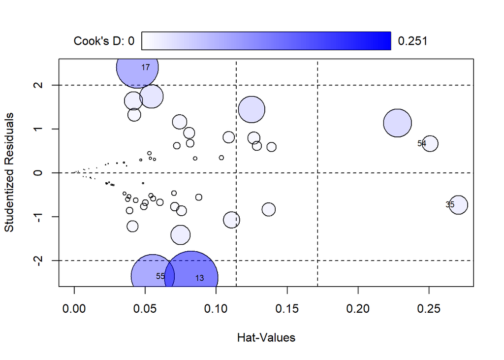

```r
set.seed(21003)
library(car)
casos_influyentes <- influencePlot(modelo_RLOG_glm, id = list(cex = 0.7))
```

```r
print(casos_influyentes)
```

```
##       StudRes        Hat      CookD
## 13 -2.3995113 0.08257318 0.25088119
## 17  2.4104006 0.04447456 0.15365552
## 35 -0.7253204 0.27051239 0.03094073
## 54  0.6704511 0.25072544 0.02333366
## 55 -2.3530724 0.05519374 0.16490563
```

Podemos ver que están los puntos 13, 17, 35, 54 y 55 “peligrando”, pero no son considerados influyentes, ya que no superan el umbral crítico. Por lo tanto, se cumple la condición de que las estimaciones de los coeficientes del modelo no están dominadas por casos influyentes.

Poder predictivo:

```r
# Usar las variables seleccionadas en el modelo final (sin Waist.Girth)
vars_finales <- predictors(resultado_rfe)
vars_finales <- vars_finales[vars_finales != "Waist.Girth"]

# Subconjunto de prueba con solo esas variables
x_test <- datos_pru %>%
  select(all_of(vars_finales))
# Convertir EN a factor con los mismos niveles
datos_pru$EN <- factor(datos_pru$EN, levels = c("No_sobrepeso", "Sobrepeso"))
```

```r
# Predecir probabilidades
probs_test <- predict(modelo_RLOG_glm, newdata = x_test, type = "response")

# Clasificar usando umbral 0.5
clase_pred_test <- ifelse(probs_test >= 0.5, "Sobrepeso", "No_sobrepeso")
clase_pred_test <- factor(clase_pred_test, levels = c("No_sobrepeso", "Sobrepeso"))
```

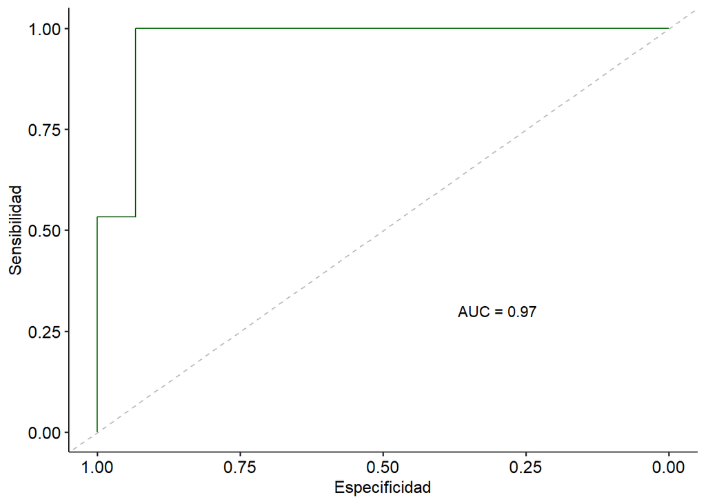

```r
library(pROC)
roc_test <- roc(datos_pru$EN, probs_test, levels = c("No_sobrepeso", "Sobrepeso"), direction = "<")

# Graficar curva ROC
g_roc_test <- ggroc(roc_test, color = "darkgreen") +
  geom_abline(intercept = 1, slope = 1, linetype = "dashed", color = "gray") +
  annotate("text", x = 0.3, y = 0.3, label = paste("AUC =", round(auc(roc_test), 2))) +
  xlab("Especificidad") + ylab("Sensibilidad") +
  theme_pubr()

print(g_roc_test)
```

```r
library(caret)

conf_test <- confusionMatrix(clase_pred_test, datos_pru$EN)
print(conf_test)
```

```
## Confusion Matrix and Statistics
##
##               Reference
## Prediction     No_sobrepeso Sobrepeso
##   No_sobrepeso           14         0
##   Sobrepeso               1        15
##
##                Accuracy : 0.9667
##                  95% CI : (0.8278, 0.9992)
##     No Information Rate : 0.5
##     P-Value [Acc > NIR] : 2.887e-08
##
##                   Kappa : 0.9333
##
##  Mcnemar's Test P-Value : 1
##
##             Sensitivity : 0.9333
##             Specificity : 1.0000
##          Pos Pred Value : 1.0000
##          Neg Pred Value : 0.9375
##              Prevalence : 0.5000
##          Detection Rate : 0.4667
##    Detection Prevalence : 0.4667
##       Balanced Accuracy : 0.9667
##
##        'Positive' Class : No_sobrepeso
##
```

Podemos concluir que el modelo de regresión logística tiene un excelente poder predictivo. Ya que clasifica correctamente el 96.7% de los casos. Además, mantiene un equilibrio entre sensibilidad y especificidad, y los indicadores de precisión y significancia estadística refuerzan la confiabilidad del modelo.